This notebook reproduces the verification examples presented in the paper. It includes the semi-infinite tensile fracture benchmark with prescribed exponential normal loading for impermeable and permeable fracture surfaces, the tensile fracture benchmark with prescribed exponential pore pressure, and the semi-infinite shear fracture benchmark with uniform shear loading over a finite region. The examples compare the numerical solutions obtained with the boundary integral formulation and asymptotics-informed collocation method against the corresponding analytical and semi-analytical reference solutions.

# Imports and setup

```python
from pathlib import Path
import numpy as np
from scipy.optimize import curve_fit
from scipy.special import dawsn
from scipy.interpolate import interp1d
```

```python
import matplotlib.pyplot as plt
from matplotlib.ticker import FormatStrFormatter

%matplotlib inline

#y_ticks
plt.rcParams['ytick.right'] = True
plt.rcParams['ytick.left'] = True
plt.rcParams['ytick.labelleft'] = True
plt.rcParams['ytick.minor.visible'] = True
plt.rcParams['ytick.direction'] = 'out'
plt.rcParams['ytick.labelsize'] = 15

#x_ticks
plt.rcParams['xtick.top'] = False
plt.rcParams['xtick.minor.visible'] = True
plt.rcParams['xtick.direction'] = 'out'
plt.rcParams['xtick.labelsize'] = 15
plt.rcParams['xtick.major.pad'] = 10

#general
plt.rcParams['font.sans-serif'] = ['Arial', 'DejaVu Sans']
plt.rcParams['figure.autolayout'] = True
plt.rcParams['animation.html'] = 'jshtml'
```

```python
from src.poroelastic_kernels import p_sm, sigma_xx_sm, sigma_yy_sm, p_em, sigma_xx_em, sigma_yy_em
from src.solvers_tensile_fracture import \
    solve_tensile_prescribed_loading_impermeable_surfaces, \
    solve_tensile_prescribed_loading_permeable_surfaces, \
    solve_tensile_prescribed_pore_pressure
from src.solvers_shear_fracture import solve_shear_prescribed_loading

%load_ext autoreload
%autoreload 2
```

The folder `data/precomputed_results` contains the precomputed profiles used in this Jupyter notebook. Alternatively, the Mathematica notebook `auxiliary_analytical_calculations.nb` can be used to regenerate these datasets and save them to `data/results`.

```python
REPO_ROOT = Path.cwd().parent
data_folder = REPO_ROOT / 'data' / 'precomputed_results'
# data_folder = REPO_ROOT / 'data' / "results"  # use this for data regenerated from Mathematica
```

# Steadily moving fluid source and edge dislocation solutions (Section 3)

```python
nu_u = 0.3
nu = 0.2

beta = (nu_u - nu) / (1 - nu)
xi_range = np.linspace(-10, 10, 10_000)
```

## Steadily moving fluid source (Section 3.1)

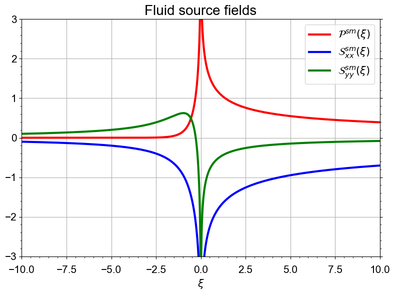

```python
plt.figure(figsize=(8, 6))

plt.plot(xi_range, p_sm(xi_range), color='red', linewidth=3, label=r'$\mathcal{P}^{sm}(\xi)$')
plt.plot(xi_range, sigma_xx_sm(xi_range), color='blue', linewidth=3, label=r'$\mathcal{S}^{sm}_{xx}(\xi)$')
plt.plot(xi_range, sigma_yy_sm(xi_range), color='green', linewidth=3, label=r'$\mathcal{S}^{sm}_{yy}(\xi)$')

plt.xlabel(r'$\xi$', fontsize=15)

plt.title('Fluid source fields', fontsize=20)

plt.legend(fontsize=15, loc=1)

plt.xlim(-10, 10)
plt.ylim(-3, 3)

plt.grid()

plt.show()
```

## Steadily moving edge dislocation (Section 3.2)

```python
xi_range_neg = xi_range[xi_range<0]
xi_range_pos = xi_range[xi_range>0]
```

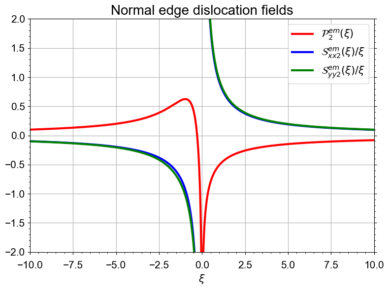

```python
plt.figure(figsize=(8, 6))

plt.plot(xi_range, p_em(xi_range), color='red', linewidth=3, label=r'$\mathcal{P}^{em}_2(\xi)$')

plt.plot(xi_range_neg, sigma_xx_em(xi_range_neg, beta), color='blue', linewidth=3)
plt.plot(xi_range_pos, sigma_xx_em(xi_range_pos, beta), color='blue', linewidth=3, \
         label=r'$\mathcal{S}^{em}_{xx2}(\xi)/\xi$')

plt.plot(xi_range_neg, sigma_yy_em(xi_range_neg, beta), color='green', linewidth=3)
plt.plot(xi_range_pos, sigma_yy_em(xi_range_pos, beta), color='green', linewidth=3, \
         label=r'$\mathcal{S}^{em}_{yy2}(\xi)/\xi$')

plt.xlabel(r'$\xi$', fontsize=15)

plt.title('Normal edge dislocation fields', fontsize=20)

plt.legend(fontsize=15, loc=1)

plt.xlim(-10, 10)
plt.ylim(-2, 2)

plt.grid()

plt.show()
```

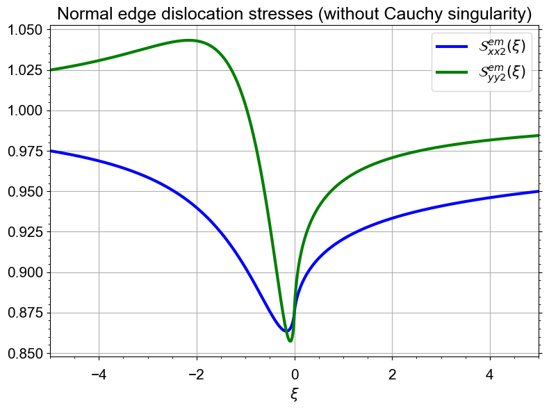

```python
plt.figure(figsize=(8, 6))

plt.plot(xi_range, xi_range * sigma_xx_em(xi_range, beta), color='blue', linewidth=3,
         label=r'$\mathcal{S}^{em}_{xx2}(\xi)$')

plt.plot(xi_range, xi_range * sigma_yy_em(xi_range, beta), color='green', linewidth=3, \
         label=r'$\mathcal{S}^{em}_{yy2}(\xi)$')

plt.xlabel(r'$\xi$', fontsize=15)

plt.title('Normal edge dislocation stresses (without Cauchy singularity)', fontsize=18)

plt.legend(fontsize=15, loc=1)

plt.xlim(-5, 5)

plt.grid()

plt.show()
```

# Verification tests (Section 7)

## Semi-infinite tensile fracture under exponential loading (Section 7.1)

### Impermeable fracture surfaces (Section 7.1.1)

```python
num_points = 300

xi_range = np.logspace(-8, 10, num_points)
xi_mid_range = 0.5 * (xi_range[1:] + xi_range[:-1])

K_analyt_func = lambda beta, A: (8 * np.sqrt(1 + 2 * A) * A ** (3/2) * (1 - beta)) / \
                                (np.sqrt(np.pi) * (np.sqrt(1 + 2 * A) * (A - beta) + beta))

K_elastic_func = lambda A: 8 * (A / np.pi) ** 0.5

pres_coef_func = lambda eta, beta, A: (A * (-1 + (1 + 2*A) ** 0.5) * beta) / (((2*A + 1) ** 0.5 * (A - beta) + beta) * eta)
```

#### Dependence of $\mathcal{K}$ on $\beta$

```python
A_range = np.logspace(-2, 2, 5)
beta_range = np.linspace(0, 0.5, 100)

K_num = [
    [solve_tensile_prescribed_loading_impermeable_surfaces([beta_cur, A_cur], xi_range, xi_mid_range)[-1]
     for beta_cur in beta_range] for A_cur in A_range
]

K_analyt = [
    [K_analyt_func(beta_cur, A_cur)
     for beta_cur in beta_range] for A_cur in A_range
]

K_elastic = [
    K_elastic_func(A_cur) for A_cur in A_range
]
```

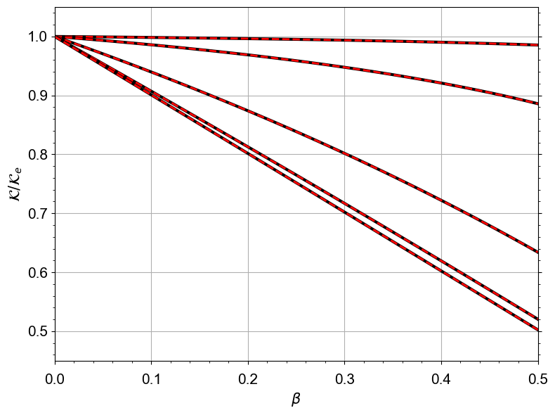

```python
plt.figure(figsize=(8, 6))

for i in range(A_range.shape[0]):
    plt.plot(beta_range, K_num[i] / K_elastic[i], color='black', linewidth=3)
    plt.plot(beta_range, K_analyt[i] / K_elastic[i], linestyle='--', color='red', linewidth=2)

plt.xlim(0, 0.5)
plt.ylim(0.45, 1.05)

plt.xlabel(r'$\beta$', fontsize=15)
plt.ylabel(r'$\mathcal{K}/\mathcal{K}_e$', fontsize=15)

plt.grid()

plt.show()
```

#### Dependence of $\mathcal{K}$ on $\mathcal{A}$

```python
A_range = np.logspace(-4, 4, 100)
beta_range = np.linspace(0, 0.5, 5)

K_num = [
    [solve_tensile_prescribed_loading_impermeable_surfaces([beta_cur, A_cur], xi_range, xi_mid_range)[-1]
     for A_cur in A_range] for beta_cur in beta_range
]

K_analyt = [
    [K_analyt_func(beta_cur, A_cur)
     for A_cur in A_range] for beta_cur in beta_range
]

K_elastic = K_elastic_func(A_range)
```

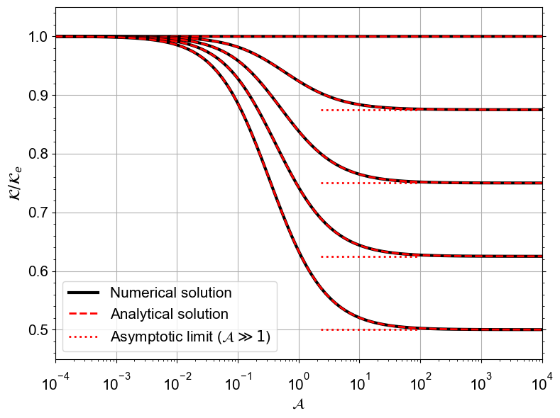

```python
plt.figure(figsize=(8, 6))

filter_ = np.logical_and(A_range > 2, A_range <= 1e2)

for i in range(beta_range.shape[0]):
    plt.plot(A_range, K_num[i] / K_elastic, color='black', linewidth=3)
    plt.plot(A_range, K_analyt[i] / K_elastic, linestyle='--', color='red', linewidth=2)

    if i > 0:
        plt.plot(A_range[filter_], np.ones_like(A_range[filter_]) * (1 - beta_range[i]),
                 linestyle=':', color='red', linewidth=2)

plt.plot([-1], [-1], color='black', linewidth=3, label='Numerical solution')
plt.plot([-1], [-1], linestyle='--', color='red', linewidth=2, label='Analytical solution')
plt.plot([-1], [-1], linestyle=':', color='red', linewidth=2, label=r'Asymptotic limit ($\mathcal{A} \gg 1$)')

plt.xlim(1e-4, 1e4)
plt.ylim(0.45, 1.05)

plt.xscale('log')

plt.xlabel(r'$\mathcal{A}$', fontsize=15)
plt.ylabel(r'$\mathcal{K}/\mathcal{K}_e$', fontsize=15)

plt.legend(fontsize=15)

plt.grid()

plt.show()
```